# MEPS Insurance Analysis

Rose Danuser

March 31, 2025

```r
library(pacman)
p_load(dplyr, knitr, skimr, tidyr, ggplot2, stringr, broom, gridExtra, gt, gtsummary, emmeans, readxl)

setwd("~/Downloads")
heus <- read_excel("heus_mepssample 3.2025.xls")

head(heus)
str(heus)
```

# 1. How many unique individuals were surveyed?

```r
n_distinct(heus$dupersid)
```

```
## [1] 19386
```

# 2. How many unique households were surveyed?

```r
n_distinct(heus$duid)
```

```
## [1] 10940
```

# 3. Create a table reporting means or proportions of the following: age, gender, race, family size, education, insurance status, and region.

```r
heus <- heus %>%
  mutate(across(c(female, race_bl, race_oth, eth_hisp, ed_hs, ed_hsplus, ed_col, ed_colplus, reg_midw, reg_south, reg_west, ins_mcare, ins_mcaid, ins_unins, ins_dent), as.factor))


list(
  race_bl = heus %>% count(race_bl),
  race_oth = heus %>% count(race_oth),
  eth_hisp = heus %>% count(eth_hisp)
)


heus <- heus %>%
  mutate(
    race_eth = case_when(
      eth_hisp == "Hispanic" ~ "Hispanic",
      race_bl == "Black race" ~ "Non-Hispanic Black",
      race_oth == "Other race" ~ "Non-Hispanic Other",
      TRUE ~ "Non-Hispanic White"
    ))

heus <- heus %>%
  mutate(
    edu_cat = case_when(
      ed_colplus == "1" ~ "Graduate or professional degree",
      ed_col == "College degree" ~ "Bachelor's degree or equivalent",
      ed_hsplus == "Some college education" ~ "Some college, no degree",
      ed_hs == "High school education" ~ "High school diploma",
      TRUE ~ "Less than a high school diploma"
    ),
    edu_cat = factor(edu_cat, levels = c(
      "Less than a high school diploma", "High school diploma", "Some college, no degree",
      "Bachelor's degree or equivalent", "Graduate or professional degree"
    ), ordered = TRUE)
  )

heus <- heus %>%
  mutate(
    region_cat = case_when(
      reg_midw == "Midwest" ~ "Midwest",
      reg_south == "South" ~ "South",
      reg_west == "West" ~ "West",
      TRUE ~ "Northeast"
    ),
    region_cat = factor(region_cat, levels = c("Northeast", "Midwest", "South", "West"))
  )

heus <- heus %>%
  mutate(
    insurance_cat = case_when(
      ins_unins == "Uninsured" ~ "Uninsured",
      ins_mcare == "Medicare" & ins_mcaid == "Medicaid" ~ "Dual Eligible",
      ins_mcare == "Medicare" ~ "Medicare only",
      ins_mcaid == "Medicaid" ~ "Medicaid only",
      TRUE ~ "Other/Unknown"
    ),
    insurance_cat = factor(insurance_cat, levels = c(
      "Uninsured", "Medicaid only", "Medicare only", "Dual Eligible", "Other/Unknown"))
  )

head(heus)
```

```r
mep2004 <- heus %>%
  select(age, female, race_eth, famsize, edu_cat, insurance_cat, region_cat) %>%
  tbl_summary(
    statistic = list(
      all_continuous() ~ "{mean} ({sd})",
      all_categorical() ~ "{n} ({p}%)"
    ),
    label = list(
      age ~ "Age",
      famsize ~ "Family Size",
      female ~ "Gender",
      race_eth ~ "Race/Ethnicity",
      edu_cat ~ "Education",
      insurance_cat ~ "Insurance Status",
      region_cat ~ "Region"
    )
  ) %>%
  bold_labels() %>%
  as_gt() %>%
  tab_header(
      title = "Demographic and Insurance Characteristics of the 2004 Medical Expenditure Panel Survey (MEPS) Sample (n = 19,386)"
    )

mep2004
```

Demographic and Insurance Characteristics of the 2004 Medical Expenditure Panel Survey (MEPS) Sample (n = 19,386)

| **Characteristic** | **N = 19,386**<sup>1</sup> |
| --- | --- |
| Age | 45 (17) |
| Gender |  |
| Female | 10,654 (55%) |
| Male | 8,732 (45%) |
| Race/Ethnicity |  |
| Hispanic | 4,387 (23%) |
| Non-Hispanic Black | 2,680 (14%) |
| Non-Hispanic Other | 1,267 (6.5%) |
| Non-Hispanic White | 11,052 (57%) |
| Family Size | 3.00 (1.66) |
| Education |  |
| Less than a high school diploma | 2,831 (15%) |
| High school diploma | 5,764 (30%) |
| Some college, no degree | 5,017 (26%) |
| Bachelor's degree or equivalent | 3,307 (17%) |
| Graduate or professional degree | 2,467 (13%) |
| Insurance Status |  |
| Uninsured | 3,443 (18%) |
| Medicaid only | 2,036 (11%) |
| Medicare only | 2,854 (15%) |
| Dual Eligible | 760 (3.9%) |
| Other/Unknown | 10,293 (53%) |
| Region |  |
| Northeast | 2,845 (15%) |
| Midwest | 3,851 (20%) |
| South | 7,941 (41%) |
| West | 4,749 (24%) |

<sup>1</sup> Mean (SD); n (%)

```r
gtsave(mep2004, "mep2004.docx", path = "~/Downloads")
```

# 4. Create a visualization showing the mean and 95% confidence interval of total medical expenditures (exp_total) for every 10 year age interval across the sample (e.g. less than 20, 20-29, 30-39…).

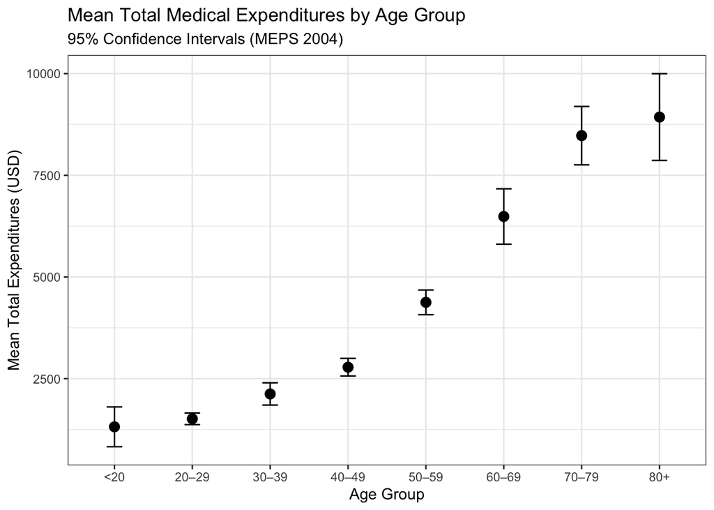

```r
# create age groups; intervals are left-inclusive and right-exclusive
heus <- heus %>%
  mutate(age_group = cut(age,
                         breaks = c(0, 20, 30, 40, 50, 60, 70, 80, Inf),
                         labels = c("<20", "20–29", "30–39", "40–49", "50–59", "60–69", "70–79", "80+"),
                         right = FALSE))
# table(heus$age_group)

# Summarize mean and 95% CI of total expenditures by age group
total_exp_byAge <- heus %>%
  group_by(age_group) %>%
  summarize(
    mean_exp = mean(exp_tot, na.rm = TRUE),
    se = sd(exp_tot, na.rm = TRUE) / sqrt(n()),
    lower = mean_exp - 1.96 * se,
    upper = mean_exp + 1.96 * se
  ) %>%
  ungroup()

# Plot point estimates with error bars representing 95% confidence intervals
tot_exp_byAge_plot <- ggplot(total_exp_byAge, aes(x = age_group, y = mean_exp)) +
  geom_point(size = 3) +
  geom_errorbar(aes(ymin = lower, ymax = upper), width = 0.2) +
  labs(
    title = "Mean Total Medical Expenditures by Age Group",
    subtitle = "95% Confidence Intervals (MEPS 2004)",
    x = "Age Group",
    y = "Mean Total Expenditures (USD)"
  ) +
  theme_bw()
tot_exp_byAge_plot
```

```r
ggsave("tot_exp_byAge_plot.png", plot = tot_exp_byAge_plot, width = 11, height = 8.5, dpi = 300, units = "in")
```

# 5. Specify a statistical model to estimate the association between insurance status (ins_) and total medical care expenses. Explain which variables you may want to control for. Explain your choice of statistical model. Create a table with results from the analysis and interpret the results.

I first estimated a base model with insurance status as the only predictor of log-transformed total medical expenditures. I then fit a fully adjusted multivariable OLS model including age, gender, race/ethnicity, education, region, and family size to account for potential confounding.

Log-transformation (log1p) was used to account for the right-skewed distribution of medical expenditures and avoid issues with zero values.

## null model

```r
# Uninsured as the reference level
heus <- heus %>%
  mutate(insurance_cat = relevel(factor(insurance_cat), ref = "Uninsured"))

# null model
m0 <- lm(log1p(exp_tot) ~ insurance_cat, data = heus)
summary(m0)
```

```
##
## Call:
## lm(formula = log1p(exp_tot) ~ insurance_cat, data = heus)
##
## Residuals:
##     Min      1Q  Median      3Q     Max
## -8.1787 -1.1817  0.5499  1.8506  7.7668
##
## Coefficients:
##                            Estimate Std. Error t value Pr(>|t|)
## (Intercept)                 3.19376    0.04712   67.78   <2e-16 ***
## insurance_catMedicaid only  2.83659    0.07730   36.70   <2e-16 ***
## insurance_catMedicare only  4.84577    0.06999   69.23   <2e-16 ***
## insurance_catDual Eligible  4.98495    0.11081   44.98   <2e-16 ***
## insurance_catOther/Unknown  2.92460    0.05444   53.73   <2e-16 ***
## ---
## Signif. codes:  0 '***' 0.001 '**' 0.01 '*' 0.05 '.' 0.1 ' ' 1
##
## Residual standard error: 2.765 on 19381 degrees of freedom
## Multiple R-squared:  0.2237, Adjusted R-squared:  0.2235
## F-statistic:  1396 on 4 and 19381 DF,  p-value: < 2.2e-16
```

## Full adjusted model; controlling for key confounders

```r
m1 <- lm(log1p(exp_tot) ~ insurance_cat + age + female + race_eth + edu_cat + region_cat + famsize, data = heus)
summary(m1)
```

```
##
## Call:
## lm(formula = log1p(exp_tot) ~ insurance_cat + age + female +
##     race_eth + edu_cat + region_cat + famsize, data = heus)
##
## Residuals:
##     Min      1Q  Median      3Q     Max
## -9.9799 -1.2368  0.4034  1.7126  8.3644
##
## Coefficients:
##                             Estimate Std. Error t value Pr(>|t|)
## (Intercept)                 2.687349   0.110046  24.420  < 2e-16 ***
## insurance_catMedicaid only  2.676437   0.073566  36.382  < 2e-16 ***
## insurance_catMedicare only  2.433502   0.085755  28.377  < 2e-16 ***
## insurance_catDual Eligible  3.358706   0.112149  29.949  < 2e-16 ***
## insurance_catOther/Unknown  2.094167   0.054795  38.218  < 2e-16 ***
## age                         0.043644   0.001545  28.250  < 2e-16 ***
## femaleMale                 -1.057277   0.037477 -28.212  < 2e-16 ***
## race_ethNon-Hispanic Black  0.229883   0.067078   3.427 0.000611 ***
## race_ethNon-Hispanic Other  0.253597   0.084663   2.995 0.002744 **
## race_ethNon-Hispanic White  0.897218   0.053707  16.706  < 2e-16 ***
## edu_cat.L                   0.677924   0.054133  12.523  < 2e-16 ***
## edu_cat.Q                  -0.077935   0.045847  -1.700 0.089169 .
## edu_cat.C                  -0.009918   0.042063  -0.236 0.813604
## edu_cat^4                   0.052110   0.038329   1.360 0.173982
## region_catMidwest           0.039176   0.063885   0.613 0.539735
## region_catSouth            -0.171575   0.057044  -3.008 0.002635 **
## region_catWest             -0.236601   0.062376  -3.793 0.000149 ***
## famsize                    -0.177328   0.012250 -14.475  < 2e-16 ***
## ---
## Signif. codes:  0 '***' 0.001 '**' 0.01 '*' 0.05 '.' 0.1 ' ' 1
##
## Residual standard error: 2.567 on 19368 degrees of freedom
## Multiple R-squared:  0.3312, Adjusted R-squared:  0.3306
## F-statistic: 564.1 on 17 and 19368 DF,  p-value: < 2.2e-16
```

```r
# adjusted means and 95% CI
em_summary <- emmeans(m1, ~ insurance_cat) %>%
  summary(type = "response") %>%
  as_tibble() %>%
  select(insurance_cat, adj_mean = response, lower.CL, upper.CL)

# vector of groups to compare against Uninsured
groups <- c("Medicaid only", "Medicare only", "Dual Eligible", "(Other/Unknown)")

pval_tbl <- purrr::map_dfr(groups, function(g) {
  contrast_label <- paste(g, "- Uninsured")
  p <- contrast(emmeans(m1, ~ insurance_cat), method = "revpairwise") %>%
    summary(type = "response") %>%
    as_tibble() %>%
    filter(contrast == contrast_label) %>%
    pull(p.value)
  tibble(
    insurance_cat = g,
    p.value = case_when(
      length(p) == 0 ~ NA_character_,
      p < 0.001 ~ "<0.001",
      TRUE ~ sprintf("%.3f", p)))
})
pval_tbl <- pval_tbl %>%
  mutate(insurance_cat = str_replace_all(insurance_cat, "[()]", ""))


final_emmeans <- left_join(em_summary, pval_tbl, by = "insurance_cat")

final_emmeans <- final_emmeans %>%
  mutate(
    `Adjusted Mean (95% CI)` = sprintf("%.2f (%.2f, %.2f)", adj_mean, lower.CL, upper.CL)
  ) %>%
  select(
    `Insurance Category` = insurance_cat,
    `Adjusted Mean (95% CI)`,
    `p-value` = p.value
  )
final_emmeans
```

Adjusted mean expenditures by insurance category, back-transformed to the original scale, are shown in Table 2. Uninsured individuals had the lowest mean expenditures (46.40; 95% CI: 41.85, 51.43). In contrast, expenditures were significantly higher among individuals with public insurance. Medicaid enrollees had a mean expenditure of 687.86 (95% CI: 607.50, 778.83), and Medicare enrollees averaged 539.29 (95% CI: 472.52, 615.47). Dual eligible individuals had the highest adjusted expenditures at 1361.81 (95% CI: 1118.89, 1657.42). All comparisons to the uninsured were statistically significant (p < 0.001).

```r
adjusted_tot_exp <- final_emmeans %>%
  gt() %>%
  cols_align(
  align = "left",
  ) %>%
  tab_header(
    title = "Table 2. Adjusted Medical Expenditures by Insurance Category",
    subtitle = "Estimates from Multivariable OLS Model, Back-Transformed from Log1p (MEPS 2004)"
  ) %>%
  tab_source_note("Adjusted for age, gender, race/ethnicity, education, region, and family size.") %>%
tab_source_note("Reference group: Uninsured")

adjusted_tot_exp
```

Table 2. Adjusted Medical Expenditures by Insurance Category

Estimates from Multivariable OLS Model, Back-Transformed from Log1p (MEPS 2004)

| Insurance Category | Adjusted Mean (95% CI) | p-value |
| --- | --- | --- |
| Uninsured | 46.40 (41.85, 51.43) | NA |
| Medicaid only | 687.86 (607.50, 778.83) | <0.001 |
| Medicare only | 539.29 (472.52, 615.47) | <0.001 |
| Dual Eligible | 1361.81 (1118.89, 1657.42) | <0.001 |
| Other/Unknown | 383.82 (359.14, 410.18) | <0.001 |

Adjusted for age, gender, race/ethnicity, education, region, and family size.  
Reference group: Uninsured

```r
gtsave(adjusted_tot_exp, "adjusted_tot_exp.docx", path = "~/Downloads")
```